# End of Lecture 2 Exercises

### Exercise 1:

Using the R chunk below, load starwars, a built-in dataset from tidyverse, into your environment and prints the first six observations. Afterwards, use starwars with ggplot to create a boxplot with gender on the x-axis and height on the y-axis.

```r
# place your code below

# load the tidyverse package
library(tidyverse)
# load starwars into the R env't
data("starwars")

head(starwars)
```

```
# A tibble: 6 × 14
  name      height  mass hair_color skin_color eye_color birth_year sex   gender
  <chr>      <int> <dbl> <chr>      <chr>      <chr>          <dbl> <chr> <chr>
1 Luke Sky…    172    77 blond      fair       blue            19   male  mascu…
2 C-3PO        167    75 <NA>       gold       yellow         112   none  mascu…
3 R2-D2         96    32 <NA>       white, bl… red             33   none  mascu…
4 Darth Va…    202   136 none       white      yellow          41.9 male  mascu…
5 Leia Org…    150    49 brown      light      brown           19   fema… femin…
6 Owen Lars    178   120 brown, gr… light      blue            52   male  mascu…
# ℹ 5 more variables: homeworld <chr>, species <chr>, films <list>,
#   vehicles <list>, starships <list>
```

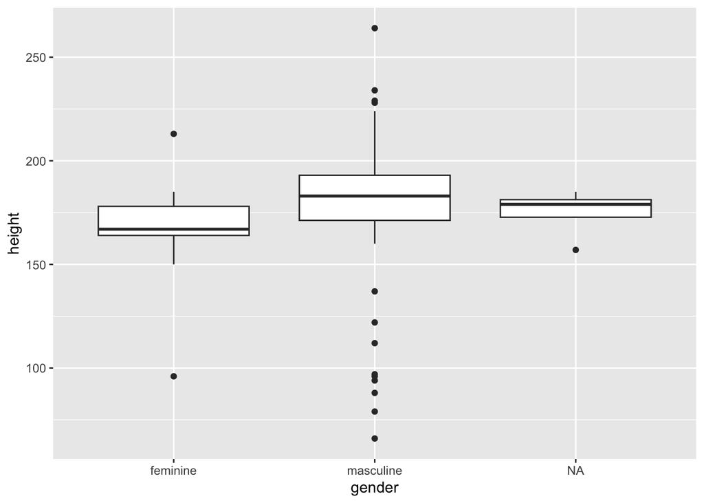

```r
ggplot(data = starwars, aes(x = gender, y = height)) +
  geom_boxplot()
```

### Exercise 2:

Below loads msleep, a built-in dataset from tidyverse, into your environment and prints the first six observations. Run the script below:

```r
data("msleep")
head(msleep)
```

```
# A tibble: 6 × 11
  name    genus vore  order conservation sleep_total sleep_rem sleep_cycle awake
  <chr>   <chr> <chr> <chr> <chr>              <dbl>     <dbl>       <dbl> <dbl>
1 Cheetah Acin… carni Carn… lc                  12.1      NA        NA      11.9
2 Owl mo… Aotus omni  Prim… <NA>                17         1.8      NA       7
3 Mounta… Aplo… herbi Rode… nt                  14.4       2.4      NA       9.6
4 Greate… Blar… omni  Sori… lc                  14.9       2.3       0.133   9.1
5 Cow     Bos   herbi Arti… domesticated         4         0.7       0.667  20
6 Three-… Brad… herbi Pilo… <NA>                14.4       2.2       0.767   9.6
# ℹ 2 more variables: brainwt <dbl>, bodywt <dbl>
```

For detailed documentation on msleep, please see: https://ggplot2.tidyverse.org/reference/msleep.html

Using msleep, create at scatter plot with sleep_total on the x axis and sleep_rem on the y axis. Do not use labs() for Exercise 2 to label your plot yet.

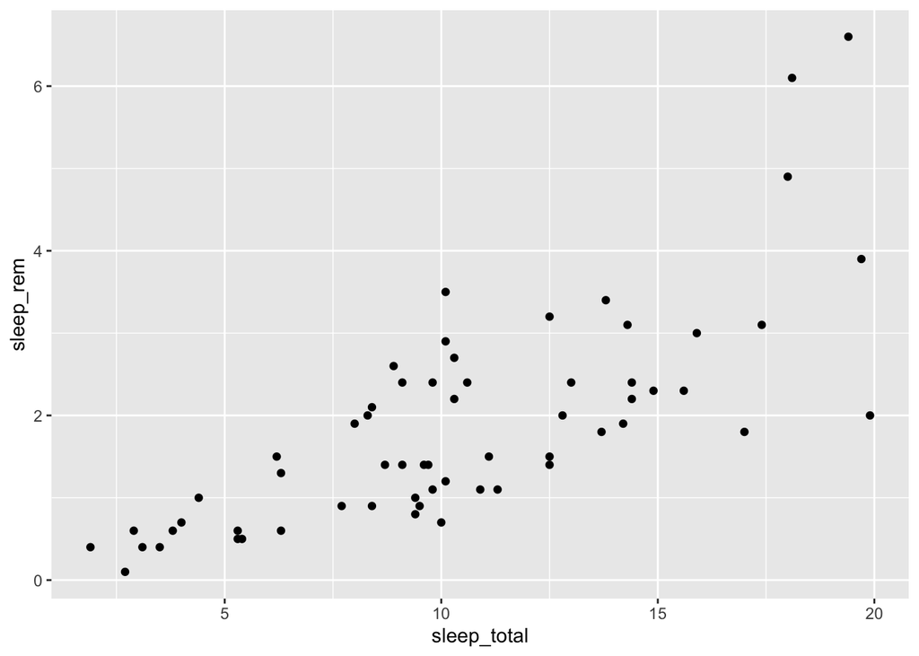

```r
# place your code below
ggplot(msleep, aes(x = sleep_total, y = sleep_rem)) +
  geom_point()
```

### Exercise 3:

Copy the code you ran for Exercise 2. This time, customize the plot by adding labs() to label the x and y axes accordingly to also include the relevant units (e.g., hrs) and include a plot title. See *Making Professional Images* for example.

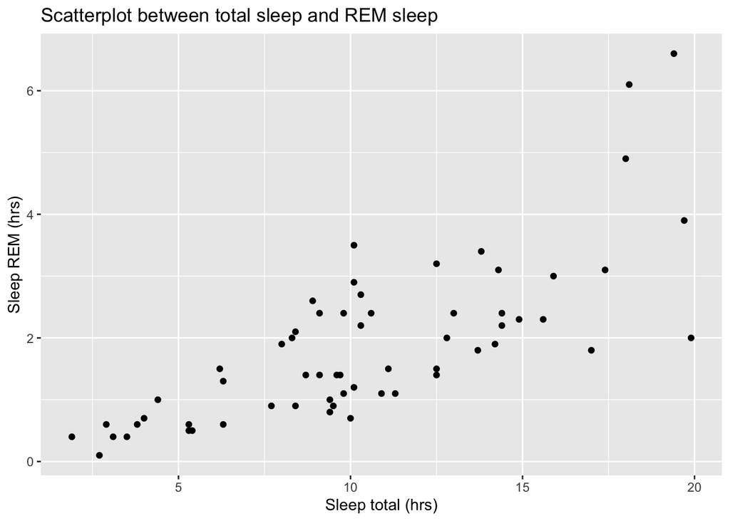

```r
# place your code below
ggplot(msleep, aes(x = sleep_total, y = sleep_rem)) +
  geom_point() +
  labs(x = "Sleep total (hrs)", y =  "Sleep REM (hrs)",
       title = "Scatterplot between total sleep and REM sleep")
```

### Exercise 4:

Copy the code you ran for Exercise 3. This time, customize the plot by adding geom_smooth(method = “lm”) to add a trend line.

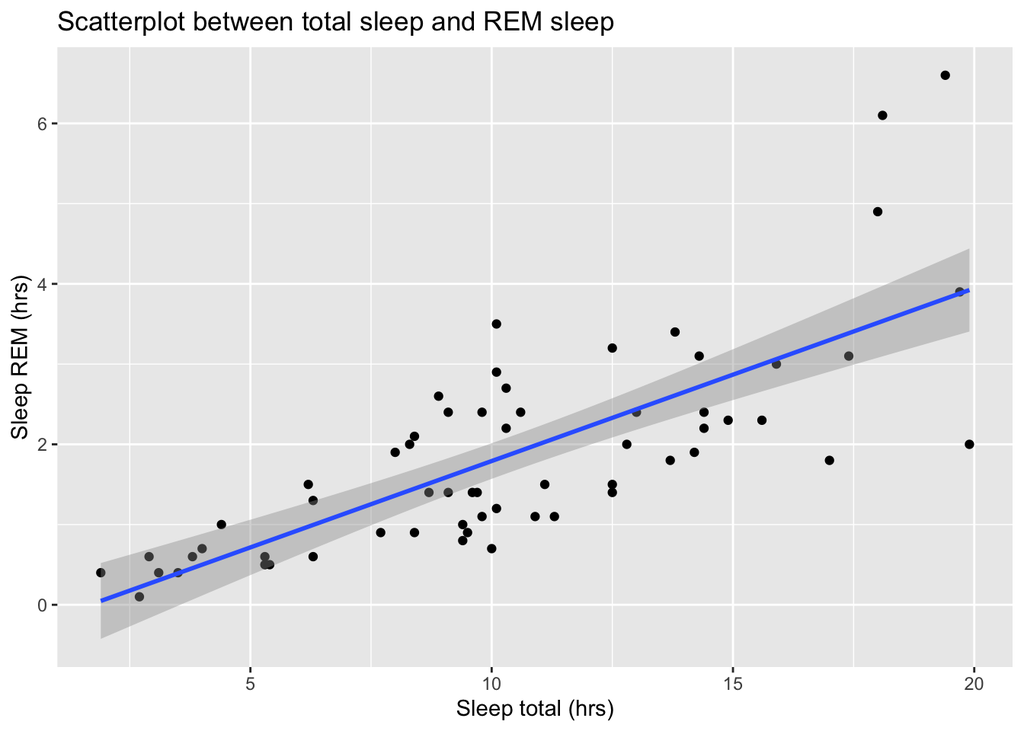

```r
# place your code below
ggplot(msleep, aes(x = sleep_total, y = sleep_rem)) +
  geom_point() +
  labs(x = "Sleep total (hrs)", y =  "Sleep REM (hrs)",
       title = "Scatterplot between total sleep and REM sleep") +
  geom_smooth(method = "lm")
```